# Automate Terraform with GitHub Actions

- 11min
- |
- HCP Terraform
- Terraform

GitHub Actions add continuous integration to GitHub repositories to automate your software builds, tests, and deployments. Automating Terraform with CI/CD enforces configuration best practices, promotes collaboration, and automates the Terraform workflow.

HashiCorp provides GitHub Actions that integrate with the HCP Terraform API. These actions let you create your own custom CI/CD workflows to meet the needs of your organization.

In this tutorial, you will use HashiCorp's HCP Terraform GitHub Actions to create a complete Actions workflow to deploy a publicly accessible web server within an HCP Terraform workspace.

[figure not shown]

The workflow will:

1. Generate a plan for every commit to a pull request branch, which you can review in HCP Terraform.
2. Apply the configuration when you update the `main` branch.

After configuring the GitHub Action, you will create and merge a pull request to test the workflow.

HCP Terraform's built-in support for GitHub webhooks can accomplish this generic workflow. However, by using HashiCorp's HCP Terraform GitHub Actions, you can create a custom workflow with additional steps before or after your Terraform operations.

## Prerequisites

This tutorial assumes that you are familiar with the Terraform and HCP Terraform workflows. If you are new to Terraform, complete the Get Started tutorials first. If you are new to HCP Terraform, complete the HCP Terraform Get Started tutorials first.

For this tutorial, you will need:

- A [GitHub account](https://github.com/join)
- A [HCP Terraform account](https://app.terraform.io/session)
- An [AWS account](https://aws.amazon.com/account/)

Note

This tutorial will provision resources that qualify under the [AWS free-tier](https://aws.amazon.com/free/). If your account doesn't qualify under the AWS free-tier, we are not responsible for any charges that you may incur.

## Create an HCP Terraform team token

Navigate to your organization's settings page and click **Teams**. Click **Create a team** and specify `GitHub Actions` in the **Team name** field. Leave all permissions set to their default values.

Next, navigate to the **API tokens** page in your organization's settings, click **Team Tokens**, and then click **Create a team token**.

Choose your **GitHub Actions** team, leave the **Expiration** set to the default value of **30 days**, then click **Create**.

Save this token in a safe place. You will add it to GitHub later as a secret, so the Actions workflow can authenticate to HCP Terraform.

## Create the HCP Terraform workspace

The GitHub Action you create will connect to HCP Terraform to plan and apply your configuration. Before you set up the Actions workflow, you must create a workspace and add your AWS credentials as workspace variables.

First, create a new HCP Terraform workspace named `learn-terraform-github-actions`.

Go to the **Create a new Workspace** page and select **API-driven workflow**.

Name your workspace `learn-terraform-github-actions` and click **Create workspace**.

Now, find the AWS credentials you want to use for the workspace, or create a new key pair in the [IAM console](https://console.aws.amazon.com/iam/home?#security_credential). On your workspace's overview page click **Variables** in the left navigation bar. Then, add the following as **Environment Variables** for your `learn-terraform-github-actions` workspace.

[output not shown]

Tip

If you have temporary AWS credentials, you must also add your `AWS_SESSION_TOKEN` as an environment variable.

HCP Terraform will use these credentials to authenticate to AWS.

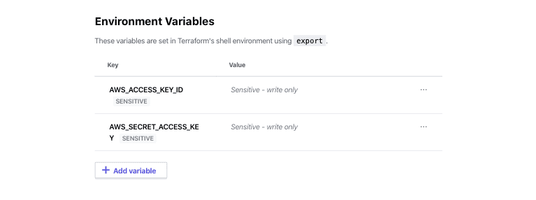

Tip

This tutorial uses IAM user authentication. You can use any authentication method described in the [AWS provider documentation](https://registry.terraform.io/providers/hashicorp/aws/latest/docs#environment-variables).

Next, give your GitHub Actions team permission to run plan and apply runs in this workspace. Navigate to the workspace's **Settings** page, click **Team Access**, then click **Add team and permissions**.

On the next page, choose **GitHub Actions** from the **Team** dropdown, choose the **Write** permission group, then click **Update permissions**.

## Set up a GitHub repository

In your browser, navigate to the [Learn Terraform GitHub Actions](https://github.com/hashicorp-education/learn-terraform-github-actions) template repository.

Select **Use this template**, then select **Create a new repository**.

[figure not shown]

In the **Owner** dropdown, select your personal GitHub account.

Next, enter `learn-terraform-github-actions` as the **Repository name**.

Finally, select **Public** and click **Create repository from template**.

In your new repository, navigate to the **Settings** page. Open the **Secrets and variables** menu, then select **Actions**.

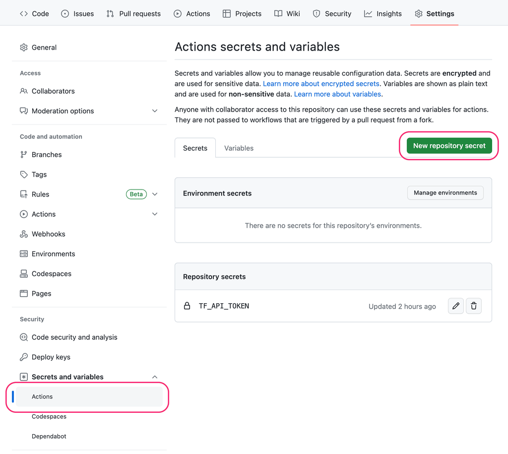

Now, select **New repository secret**. Create a secret named `TF_API_TOKEN`, setting the HCP Terraform API token you created in the previous step as the value.

Then, clone your forked repository to your local machine. Remember to replace `YOUR-USER-NAME` with your GitHub username if you are using the command below.

```
$ git clone git@github.com:YOUR-USER-NAME/learn-terraform-github-actions
```

## Review Actions workflows

There are several files in your local repository.

- [`main.tf`](https://github.com/hashicorp-education/learn-terraform-github-actions/blob/main/main.tf) contains Terraform configuration to deploy a publicly accessible EC2 instance.
- [`.github/workflows/terraform-plan.yml`](https://github.com/hashicorp-education/learn-terraform-github-actions/blob/main/.github/workflows/terraform-plan.yml) defines the Actions workflow that runs Terraform plan.
- [`.github/workflows/terraform-apply.yml`](https://github.com/hashicorp-education/learn-terraform-github-actions/blob/main/.github/workflows/terraform-apply.yml) defines the Actions workflow that runs Terraform apply.

### Review Terraform plan workflow

In your editor, open `.github/workflows/terraform-plan.yml`.

The first line defines the name of the Actions workflow.

.github/workflows/terraform-plan.yml

```
name: 'Terraform Plan'
## ...
```

Next, the configuration states that this workflow should only run on pull requests. It also defines environment variables used by the workflow.

.github/workflows/terraform-plan.yml

```
## ...
on:
  pull_request:

env:
  TF_CLOUD_ORGANIZATION: "YOUR-ORGANIZATION-HERE"
  TF_API_TOKEN: "${{ secrets.TF_API_TOKEN }}"
  TF_WORKSPACE: "learn-terraform-github-actions"
  CONFIG_DIRECTORY: "./"
## ...
```

Replace `YOUR-ORGANIZATION-HERE` with the name of your HCP Terraform organization and save the file.

Then, the configuration defines a `terraform` job, and grants the workflow permission to read the repository contents and write to pull requests.

.github/workflows/terraform-plan.yml

```
## ...
jobs:
  terraform:
    if: github.repository != 'hashicorp-education/learn-terraform-github-actions'
    name: "Terraform Plan"
    runs-on: ubuntu-latest
    permissions:
      contents: read
      pull-requests: write
    steps:
## ...
```

The workflow defines several steps.

- **Checkout** checks out the repository. [Uses](https://docs.github.com/en/actions/reference/workflow-syntax-for-github-actions#jobsjob_idstepsuses) defines the GitHub action or Docker image to run that specific step. The checkout step uses GitHub's `actions/checkout@v3` action.

  .github/workflows/terraform-plan.yml

  ```
  ## ...
  - name: Checkout
    uses: actions/checkout@v3
  ## ...
  ```

- **Upload Configuration** uploads the Terraform configuration to HCP Terraform and marks it as [speculative](https://developer.hashicorp.com/terraform/cloud-docs/api-docs/configuration-versions#request-body) so it cannot modify infrastructure.

  .github/workflows/terraform-plan.yml

  ```
  ## ...
  - name: Upload Configuration
    uses: hashicorp/tfc-workflows-github/actions/upload-configuration@v1.0.0
    id: plan-upload
    with:
      workspace: ${{ env.TF_WORKSPACE }}
      directory: ${{ env.CONFIG_DIRECTORY }}
      speculative: true
  ## ...
  ```

- **Create Plan Run** creates a speculative plan run in HCP Terraform using the configuration uploaded in the previous step.

  .github/workflows/terraform-plan.yml

  ```
  ## ...
  - name: Create Plan Run
    uses: hashicorp/tfc-workflows-github/actions/create-run@v1.0.0
    id: plan-run
    with:
      workspace: ${{ env.TF_WORKSPACE }}
      configuration_version: ${{ steps.plan-upload.outputs.configuration_version_id }}
      plan_only: true
  ## ...
  ```

- **Get Plan Output** extracts the plan output from the speculative run.

  .github/workflows/terraform-plan.yml

  ```
  ## ...
  - name: Get Plan Output
    uses: hashicorp/tfc-workflows-github/actions/plan-output@v1.0.0
    id: plan-output
    with:
      plan: ${{ fromJSON(steps.plan-run.outputs.payload).data.relationships.plan.data.id }}
  ## ...
  ```

- **Update PR** adds a comment to the pull request with a link to the run in HCP Terraform. It also removes any previous comments added by this workflow.

  .github/workflows/terraform-plan.yml

  ```
  ## ...
  - name: Update PR
    uses: actions/github-script@v6
    id: plan-comment
    with:
      github-token: ${{ secrets.GITHUB_TOKEN }}
      script: |
        // 1. Retrieve existing bot comments for the PR
        const { data: comments } = await github.rest.issues.listComments({
          owner: context.repo.owner,
          repo: context.repo.repo,
          issue_number: context.issue.number,
        });
        const botComment = comments.find(comment => {
          return comment.user.type === 'Bot' && comment.body.includes('HCP Terraform Plan Output')
        });
        const output = `#### HCP Terraform Plan Output
            \`\`\`
            Plan: ${{ steps.plan-output.outputs.add }} to add, ${{ steps.plan-output.outputs.change }} to change, ${{ steps.plan-output.outputs.destroy }} to destroy.
            \`\`\`
            [HCP Terraform Plan](${{ steps.plan-run.outputs.run_link }})
            `;
        // 3. Delete previous comment so PR timeline makes sense
        if (botComment) {
          github.rest.issues.deleteComment({
            owner: context.repo.owner,
            repo: context.repo.repo,
            comment_id: botComment.id,
          });
        }
        github.rest.issues.createComment({
          issue_number: context.issue.number,
          owner: context.repo.owner,
          repo: context.repo.repo,
          body: output
        });
  ```

### Review Terraform apply workflow

In your editor, open `.github/workflows/terraform-apply.yml`.

The first line defines the name of the Actions workflow.

.github/workflows/terraform-apply.yml

```
name: 'Terraform Apply'
## ...
```

Next, the configuration states that this workflow should only run on pushes to the `main` branch, which includes Pull Request merges to `main`. It also defines environment variables used by the workflow.

.github/workflows/terraform-apply.yml

```
## ...
on:
  push:
    branches:
      - main

env:
  TF_CLOUD_ORGANIZATION: "YOUR-ORGANIZATION-HERE"
  TF_API_TOKEN: "${{ secrets.TF_API_TOKEN }}"
  TF_WORKSPACE: "learn-terraform-github-actions"
  CONFIG_DIRECTORY: "./"
## ...
```

Replace `YOUR-ORGANIZATION-HERE` with the name of your HCP Terraform organization and save the file.

Then, the configuration defines a `terraform` job, and grants the workflow permission to read the repository contents.

.github/workflows/terraform-apply.yml

```
## ...
jobs:
  terraform:
    if: github.repository != 'hashicorp-education/learn-terraform-github-actions'
    name: "Terraform Apply"
    runs-on: ubuntu-latest
    permissions:
      contents: read
    steps:
## ...
```

The workflow defines several steps.

- **Checkout** checks out the current configuration. [Uses](https://docs.github.com/en/actions/reference/workflow-syntax-for-github-actions#jobsjob_idstepsuses) defines the action/Docker image to run that specific step. The checkout step uses GitHub's `actions/checkout@v3` action.

  .github/workflows/terraform-apply.yml

  ```
  ## ...
  - name: Checkout
    uses: actions/checkout@v3
  ## ...
  ```

- **Upload Configuration** uploads the Terraform configuration to HCP Terraform.

  .github/workflows/terraform-apply.yml

  ```
  ## ...
  - name: Upload Configuration
    uses: hashicorp/tfc-workflows-github/actions/upload-configuration@v1.0.0
    id: apply-upload
    with:
      workspace: ${{ env.TF_WORKSPACE }}
      directory: ${{ env.CONFIG_DIRECTORY }}
  ## ...
  ```

- **Create Apply Run** creates a Terraform apply run using the configuration uploaded in the previous step.

  .github/workflows/terraform-apply.yml

  ```
  ## ...
  - name: Create Apply Run
    uses: hashicorp/tfc-workflows-github/actions/create-run@v1.0.0
    id: apply-run
    with:
      workspace: ${{ env.TF_WORKSPACE }}
      configuration_version: ${{ steps.apply-upload.outputs.configuration_version_id }}
  ## ...
  ```

- **Apply** confirms and applies the run.

  .github/workflows/terraform-apply.yml

  ```
  ## ...
  - name: Apply
    uses: hashicorp/tfc-workflows-github/actions/apply-run@v1.0.0
    if: fromJSON(steps.apply-run.outputs.payload).data.attributes.actions.IsConfirmable
    id: apply
    with:
      run: ${{ steps.apply-run.outputs.run_id }}
      comment: "Apply Run from GitHub Actions CI ${{ github.sha }}"
  ```

## Create pull request

Create a new branch in your forked repository named `update-tfc-org`.

```
$ git checkout -b 'update-tfc-org'
```

Now commit the org name changes you made to the workflow files.

```
$ git add .github/workflows
```

Commit these changes with a message.

```
$ git commit -m 'Use our HCP Terraform organization'
```

Push these changes.

```
$ git push origin update-tfc-org
```

Next, open a pull request from the `update-tfc-org` branch. From the `base` drop-down, choose the `main` branch.

## Review and merge pull request

Navigate to your pull request. Your PR will trigger the `Terraform Plan` Actions workflow. When the workflow completes, it will add a comment with a link to the speculative plan.

[figure not shown]

Click the **HCP Terraform Plan** link to view the plan in HCP Terraform.

[figure not shown]

Terraform plans to create three resources, matching the comment in the pull request.

Merge the pull request.

## Verify EC2 instance provisioned

In GitHub, go to **Actions**, then select the pull request you just merged.

[figure not shown]

Then, click on the **Terraform Apply** workflow.

Wait for the workflow to complete.

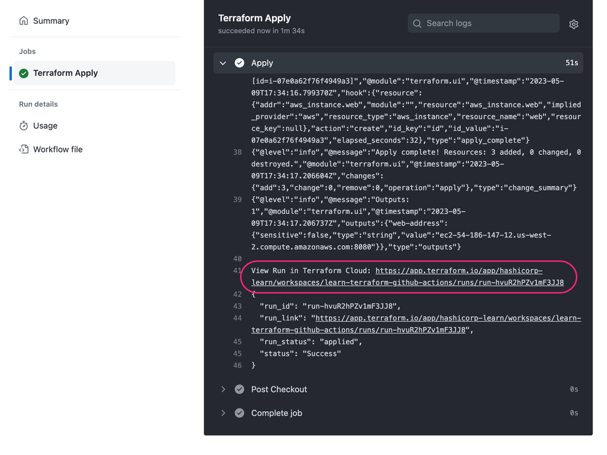

In HCP Terraform, expand the **Apply finished** section. HCP Terraform shows the resources it created and the EC2 instance's web address.

[figure not shown]

Copy the `web-address` output.

Finally, verify that the EC2 instance is publicly available. Use the curl command below with the `web-address` output value.

Note

It may take several minutes for the EC2 instance to start.

```
$ curl <web-address output>
Hello World
```

You have successfully set up a complete GitHub Actions workflow to deploy a publicly accessible web server within an HCP Terraform workspace.

### Destroy resources

Remember to destroy the resources and HCP Terraform workspace you created for this tutorial.

Go to the `learn-terraform-github-actions` workspace, queue a destroy plan, and apply it. Then, delete the workspace from HCP Terraform.

Tip

For detailed guidance on destroying resources in HCP Terraform, refer to the Clean up Cloud Resources tutorial.

## Next steps

In this tutorial, you deployed a publicly available web server by automating your HCP Terraform workflow with GitHub Actions. The resources below will help you customize the Actions workflow to fit your real-world use cases.

- [HCP Terraform Workflows for GitHub](https://github.com/hashicorp/tfc-workflows-github)
- [Continuous Integration for Terraform Modules with GitHub Actions](https://www.hashicorp.com/blog/continuous-integration-for-terraform-modules-with-github-actions/)
- Terraform and CircleCI tutorial guides you through building an automated Terraform workflow using AWS S3 as a backend.
- Running Terraform in Automation

Previous

GitHub OAuth integration

Next

Run triggers

© 2026 HashiCorp  
Licensed under the MPL 2.0 License.  
https://developer.hashicorp.com/terraform/tutorials/automation/github-actions